# New Analysis Suarez et al.

Tati Micheletti

January 24, 2019

### New analysis for manuscript reviewers

After the first round of reviews, these concerns came back as major revisions:

1. lines 119-121: I disagree with your assumption that Boreal Ecosystem Anthropogenic Disturbance polygons that did not intersect with the Global Forest Change maps were disturbances that happened before 2000 (the first year of the latter data set), just because the two products were mapped at the same spatial resolution. This is problematic because it also means you are implicitly assuming zero (or negligible) classification error in each data set. A lack of intersection could also occur because of omission/commission classification errors in the data sets. The methods used to classify disturbance and forest loss in these data sets, respectively, are very different. Thus I think it reasonable to expect that classification errors would differ between the two data sets. At minimum, I think there needs to be more thought (and discussion in the paper) about this assumption and how it could potentially impact the results. I also recommend you conduct supplementary analyses to demonstrate that your results are robust to this assumption.
2. lines 204-208: I assume that you used different subsets of your data to evaluate the relative importance of successional and alienating disturbances in an attempt to disentangle their effects (i.e. combat high collinearity between these disturbance types); this reasoning should be made more clear in the methods. Based on this assumption, I have two main concerns with this approach. First, it is not clear whether successional and alienating disturbances were also highly correlated in your two data subsets. This is because your subsetting process could still allow for enough variation in both alienating and successional disturbances across the subset of landscapes to have correlations between the two variables. For example, if a buffer had 51% alienating disturbance (the predominant disturbance type) it could still have up to 49% successional disturbance. If these are still correlated in your subsets, then interpretation of the relative importance is problematic because you have not controlled for the collinearity in your analysis. Second, even if this approach reduced the correlation between the two types of disturbance, I am concerned that subsetting the data introduces factors that could confound your interpretation of the relative importance of alienating and successional disturbances, because you are testing these effects with different data sets. For example, all else being equal, you’d expect to be less likely to detect a significant effect when using a smaller data set than using a larger one. Also, subsetting the data reduced the range of variation in your variables and this could affect the relative importance estimates if subsetting resulted in a larger decline in the range of variation in the target disturbance measure in one subset vs. the other. This is because, all else being equal, you’d expect to detect a stronger effect when the range of variation is larger. I suggest you consider these issues, and suggest that it would likely be better to test for relative importance by modeling bird density as a function of both alienating and successional disturbance using the full data set. Previous study suggests that standardized partial regression coefficients generally provide unbiased estimates of the relative importance of two predictor variables, even when predictors are correlated: see Smith et al. 2009. Confronting collinearity: comparing methods for disentangling the effects of habitat loss and fragmentation, Landscape Ecology 24:1271-1285.

*In a nutshell…*

### Question 1

**Question 1)**: Was the assumption that any disturbance polygons Boreal Ecosystem Anthropogenic Disturbance polygons that did not intersect with the Global Forest Change maps were disturbances that happened before 2000 reasonable?

**Results**: [Gif showing the thee datasets overlay](https://raw.githubusercontent.com/tati-micheletti/borealBirdsAndForestry/finalAdjustments/outputs/Tati_SuarezWW.gif)

**Conclusion**: We found that at least for Calling Lake the areas that were defined as ‘pre 2000’ in Alberto’s GIS (the one used for the submitted manuscript) match relatively well with White and Wulder’s disturbance product (which covers 1985-2011) for the same period as well as the map Fiona sent us with the dated disturbances there.

### Question 2

**Question 2)**:  
i) Are successional and alienating disturbances highly correlated?  
ii) Even if not, was the range of variation in the variables reduced?  
iii) modeling bird density as a function of both alienating and successional disturbance using the full data set (to test for relative importance).

**Results**: i and ii) The p-values for both correlation test and the linear model were significant. The R^2, however was low on both cases (`lm` = 0.0229; `cor.test` = -0.15).

```
##   percSuccess       percAliena
##  Min.   :0.0000   Min.   :0.000000
##  1st Qu.:0.0000   1st Qu.:0.000000
##  Median :0.0000   Median :0.000000
##  Mean   :0.1593   Mean   :0.057590
##  3rd Qu.:0.0000   3rd Qu.:0.002559
##  Max.   :1.0000   Max.   :1.000000
```

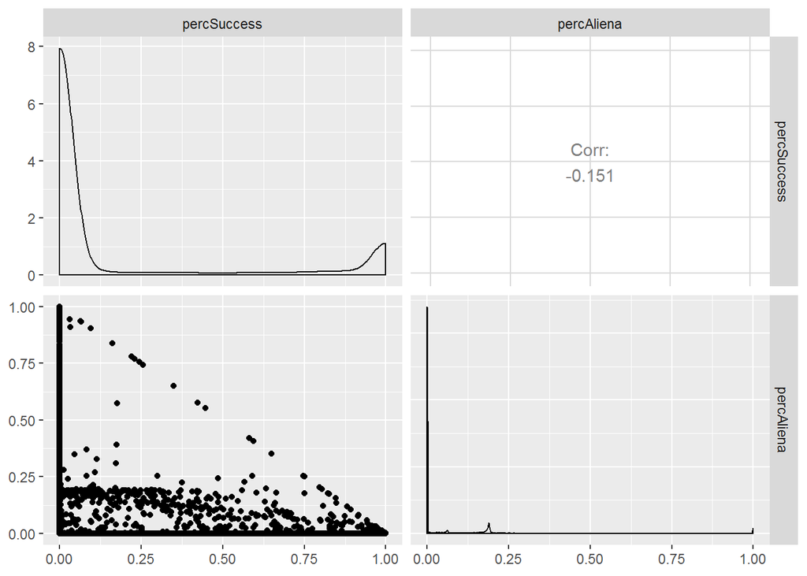

```
##
## Call:
## lm(formula = percAliena ~ percSuccess, data = local)
##
## Residuals:
##      Min       1Q   Median       3Q      Max
## -0.06902 -0.06902 -0.06902  0.00274  0.93098
##
## Coefficients:
##              Estimate Std. Error t value Pr(>|t|)
## (Intercept)  0.069024   0.001060   65.13   <2e-16 ***
## percSuccess -0.071759   0.002805  -25.58   <2e-16 ***
## ---
## Signif. codes:  0 '***' 0.001 '**' 0.01 '*' 0.05 '.' 0.1 ' ' 1
##
## Residual standard error: 0.1604 on 27872 degrees of freedom
## Multiple R-squared:  0.02294,    Adjusted R-squared:  0.0229
## F-statistic: 654.4 on 1 and 27872 DF,  p-value: < 2.2e-16
```

| subset | corr | corr.sign | r2.linMod | signif.linMod |
| --- | --- | --- | --- | --- |
| localTransitional | 0.0696087 | 0 | 0.0047985 | 0 |
| neighborhoodTransitional | -0.0804232 | 0 | 0.0063962 | 0 |
| LocalUndisturbedTransitional | NA | NA | 0.0000000 | NA |
| localPermanent | 0.0807050 | 0 | 0.0064679 | 0 |
| neighborhoodPermanent | -0.0682483 | 0 | 0.0046093 | 0 |
| LocalUndisturbedPermanent | NA | NA | 0.0000000 | NA |
| localBoth | -0.1514545 | 0 | 0.0229034 | 0 |
| neighborhoodBoth | -0.1514545 | 0 | 0.0229034 | 0 |
| LocalUndisturbedBoth | NA | NA | 0.0000000 | NA |

3. Was not performed.